# Beauty Store Analysis

Qazi Fabia Hoq

### This detailed analysis provides insights into the key metrics of a beauty startup store, focusing on supply chain efficiency, sales performance, cost management, and quality control.

## SQL Findings

### 1. Total Revenue by Product Type

- **Highest Revenue:** Skincare with $241,628.17

### 2. Top Selling Products

- **Highest Units Sold:** SKU10 in Skincare with 996 units

### 3. Average Stock Levels by Product Type

- **Highest Average Stock Levels:** Cosmetics with 58.65 units

### 5. Average Shipping Costs by Carrier

- **Highest Average Shipping Costs:** Carrier C with $5.60

### 6. Average Shipping Times by Carrier

- **Longest Shipping Times:** Carrier A with 6.14 days

### 7. Average Defect Rates by Supplier

- **Highest Average Defect Rate:** Supplier 5 with 2.67%

### 8. Average Manufacturing Costs by Product Type

- **Highest Average Manufacturing Costs:** Skincare with $48.99

## R Analysis Results

### What is the total revenue by product type?

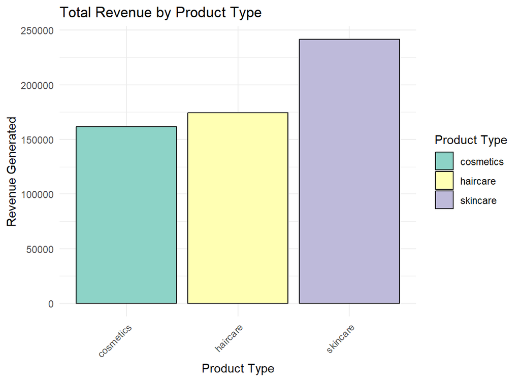

Total Revenue By Product Type

#### The revenue analysis reveals that Skincare products are the top performers, generating a substantial total revenue of $241,628.17, underscoring their strong market appeal and profitability. Haircare products also exhibit solid performance with a revenue of $174,455.42, reflecting their steady demand and market position. Meanwhile, Cosmetics products contribute approximately $161,521.27 in revenue, highlighting their significant role in the overall earnings and consistent consumer interest.

### What is the proportion of units sold by product type?

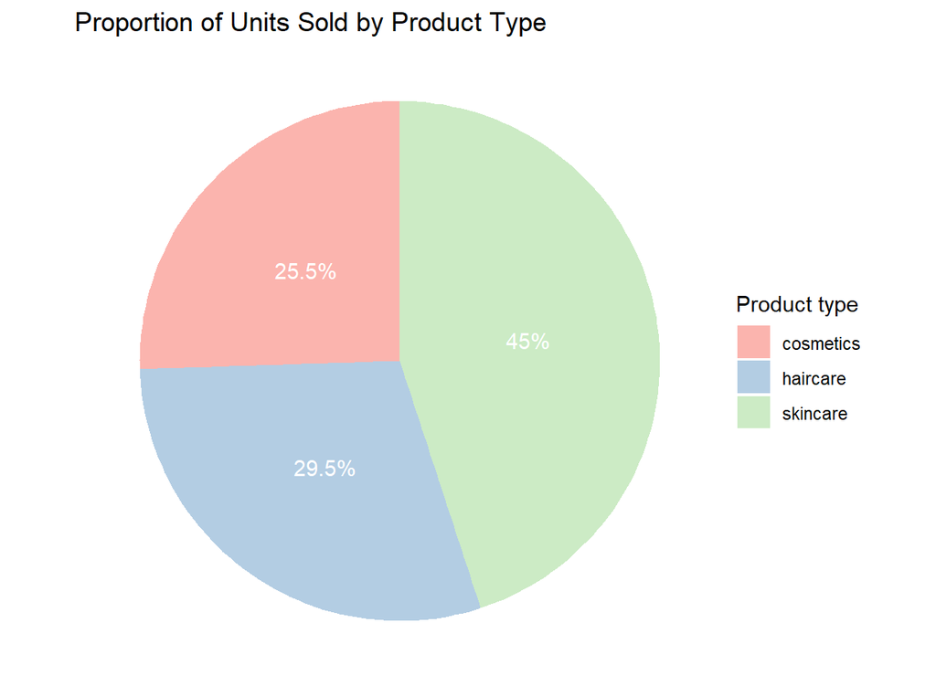

Proportions of Units Sold by Product Type

#### The distribution of units sold across product types reveals that Skincare represents 45% of the total units sold, indicating its leading role in the product lineup. Haircare follows with 29.5% of the units sold, reflecting its substantial contribution to overall sales. Cosmetics accounts for 25.5% of the units sold, highlighting its significant, though smaller, share of the market.

### What are the average lead times from different suppliers?

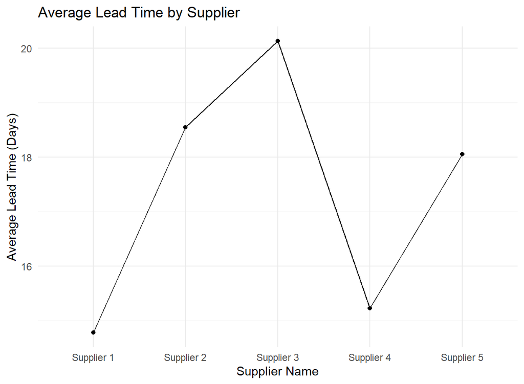

Average Lead Times By Supllier

### What is the distribution of manufacturing costs by product type?

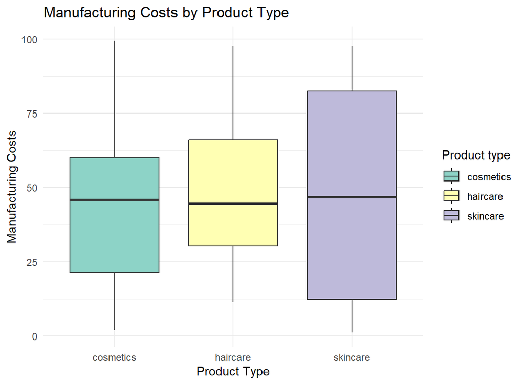

Manufacturing Cost By Product Type

### What are the average shipping costs by carrier?

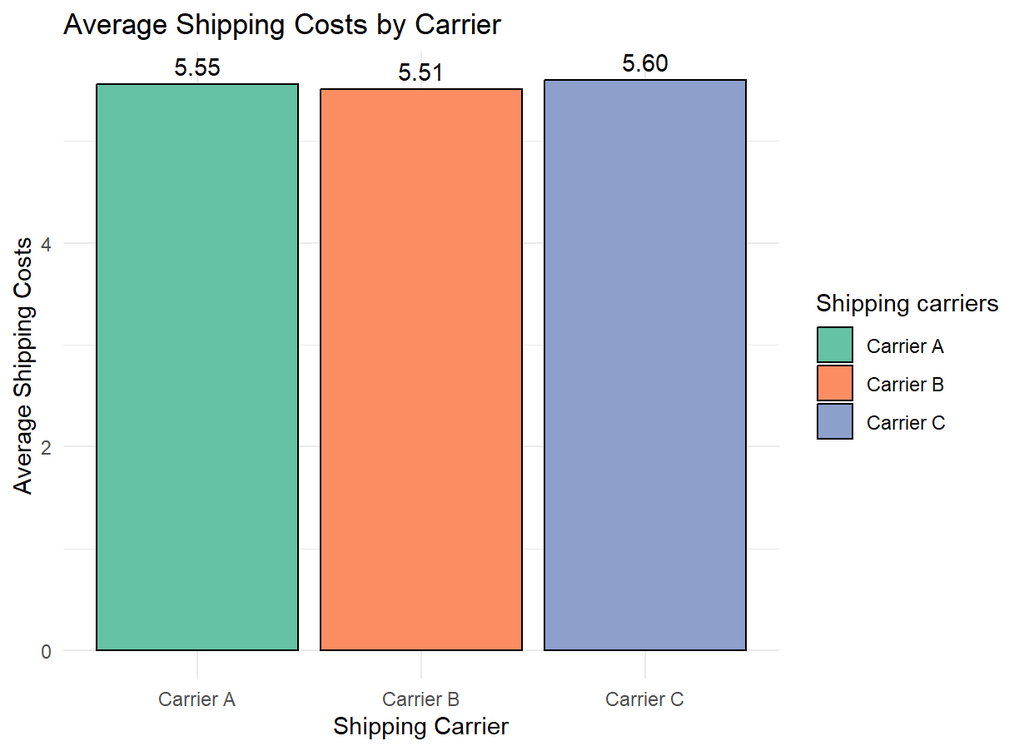

Average Shipping Costs By Carrier

#### The analysis of average shipping costs reveals that Carrier A has an average cost of $5.55, Carrier B is slightly lower at $5.51, and Carrier C has the highest average shipping cost at $5.60. This indicates a slight variation in shipping expenses among the carriers.

### What are the defect rates by supplier?

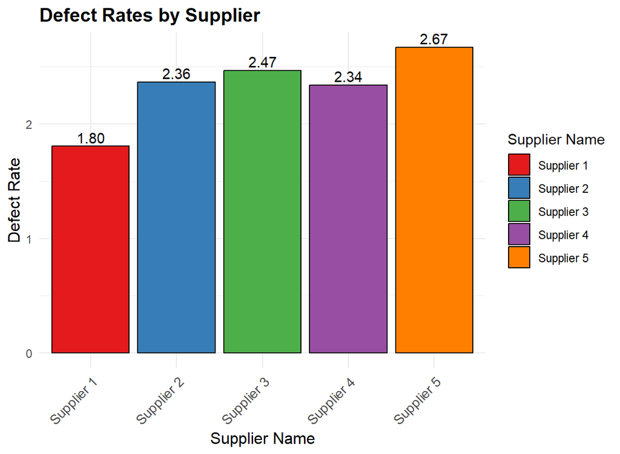

Defect Rates By Supplier

#### The average defect rates for each supplier vary as follows: Supplier 1 has an average defect rate of 1.80%, indicating relatively low defect occurrences. Supplier 2 has a slightly higher defect rate of 2.36%, while Supplier 3 shows a defect rate of 2.47%. Supplier 4 reports an average defect rate of 2.34%, which is comparable to Supplier 2. Lastly, Supplier 5 has the highest defect rate at 2.67%, reflecting a higher frequency of defects compared to the other suppliers.

### What is the relationship between revenue and manufacturing costs by product type?

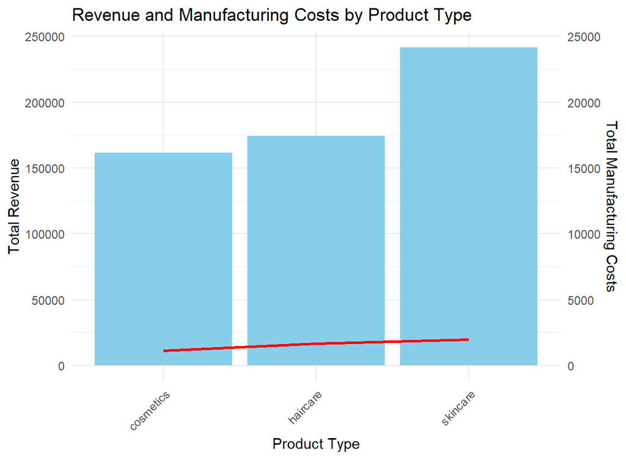

Revenue And Manufacturing Cost By Product Type

### What are the correlations between key metrics such as revenue, number of products sold, manufacturing costs, lead time, and defect rates?

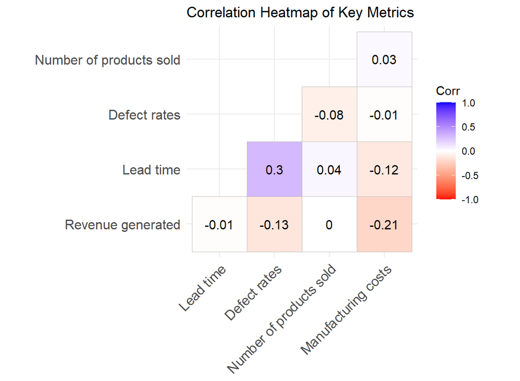

Correlation Heat Map Of Key Metrics